# Bellabeat Data Analysis Case Study

#### Finding the Daily Average Total Step

```r
# Finding the Daily Average data of Fitbit Users
# Verify data transfromation steps

daily_summary <- daily_activity %>%
  group_by(Weekday) %>%
  summarise(AvgTotalSteps = mean(TotalSteps), AvgTotalCalories = mean(Calories))
summary(daily_summary)
```

```
##       Weekday  AvgTotalSteps  AvgTotalCalories
##  Monday   :1   Min.   :6933   Min.   :2200
##  Tuesday  :1   1st Qu.:7427   1st Qu.:2283
##  Wednesday:1   Median :7559   Median :2324
##  Thursday :1   Mean   :7629   Mean   :2305
##  Friday   :1   3rd Qu.:7953   3rd Qu.:2343
##  Saturday :1   Max.   :8153   Max.   :2356
##  Sunday   :1
```

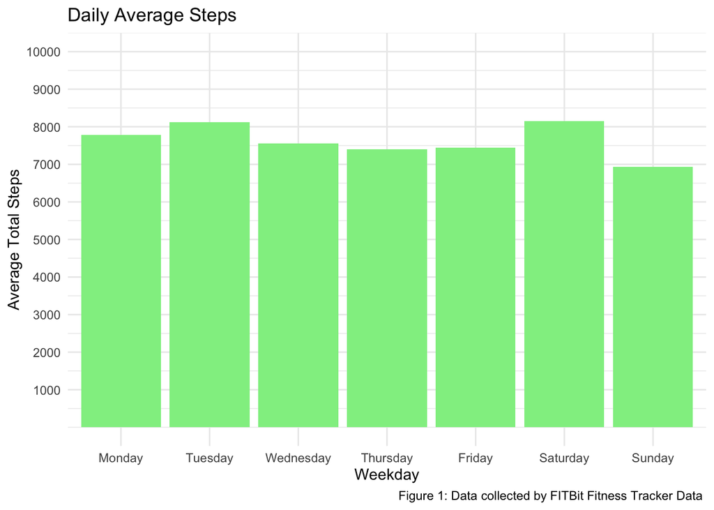

```r
ggplot(daily_summary, aes(x = Weekday, y = AvgTotalSteps)) +
  geom_bar(stat = "identity", fill = "lightgreen") +
  labs(title = "Daily Average Steps",
       x = "Weekday",
       y = "Average Total Steps",
       caption = "Figure 1: Data collected by FITBit Fitness Tracker Data ") +
  theme_minimal() +
  scale_y_continuous(limits = c(0, 10000), breaks = seq(1000, 10000, by = 1000))
```

Figure 1 and the table show the average number of steps taken per weekday, derived from data collected by a FITBit Fitness Tracker from 33 users. Based on this dataset, we observe that the highest total number of steps occurs on Tuesday and Saturday, with the lowest total steps recorded on Sunday. The calculated weekly average total steps is 7,629, reflecting overall activity levels throughout the week.

According [CDC](https://www.cdc.gov/physical-activity-basics/about/index.html) and [MedicineNet](https://www.medicinenet.com/how_many_steps_a_day_is_considered_active/article.htm), physical activity level can be categorized as follows:

- Sedentary: less than 5000 steps per day
- Low Active: 5000 to 7499 steps per day
- Somewhat Active: 7500 to 9999 steps per day
- Active: 10000 to 12,499 steps per day
- Highly Active: 12,500 or more steps per day

Referring back to the table data, the total steps of the Fitbit users average 7,629, categorizing them as **somewhat active users**. Studies suggest maintaining an activity level between 7,500 to 10,000 steps per day to improve health, including better blood sugar levels, lower blood pressure, and alleviating symptoms of depression and anxiety.

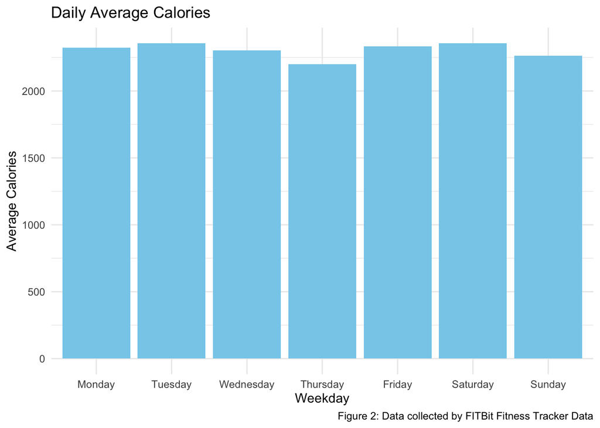

```r
# Finding the Daily Average Calories of Fitbit Users
# Create a bar chart showing the Daily Average Calories of 33 Fitbit Users
ggplot(daily_summary, aes(x = Weekday, y = AvgTotalCalories)) +
  geom_bar(stat = "identity", fill = "skyblue") +
  labs(title = "Daily Average Calories",
       x = "Weekday",
       y = "Average Calories",
       caption = "Figure 2: Data collected by FITBit Fitness Tracker Data") +
  theme_minimal()
```

Figure 2 and the table show the average calorie for each weekday, derived from data collected by a FITBit Fitness Tracker from 33 users. Based on this dataset, we observe that the daily average calorie consumption remains stable around 2300, with a minimum of 2200 and a maximum of 2356 throughout the week.